# Modulo 4 | Exercícios

Data Visualization

Autor

Rui Vilas Boas

Data de Publicação

27 de outubro de 2024

# 1 Exercicio visualização - Hypoxia

Este é um estudo sobre a pressão arterial média intraoperatória em pacientes com apneia obstrutiva do sono submetidos a procedimentos cirúrgicos de perda de peso (bariátrica). Os participantes são 281 pacientes adultos diagnosticados com apneia obstrutiva do sono nos dois anos anteriores à sua cirurgia bariátrica. Além da pressão arterial média, o conjunto de dados inclui informações sobre demografia, status de oxigênio noturno, comorbidades, tipo e duração da cirurgia, vasopressores e frequência cardíaca. Os dados foram limpos e contêm alguns dados ausentes. Não há outliers ou problemas de dados.[^1]

Para os exercicios deve utilizar o dataset hypoxia

```r
library(tidyverse)
library(janitor)
hypoxia <- read_csv("datasets/hypoxia/hypoxia.csv") |>
  clean_names()
```

## 1.1 Exercicio M4.1 Distribuições

Compara a distribuição de idades entre homens e mulheres. O gráfico deve ter um título, caption, legenda. A distribuição estar preenchido por cor “#91bfdb” e “#ef8a62”. Utiliza o tema classic.

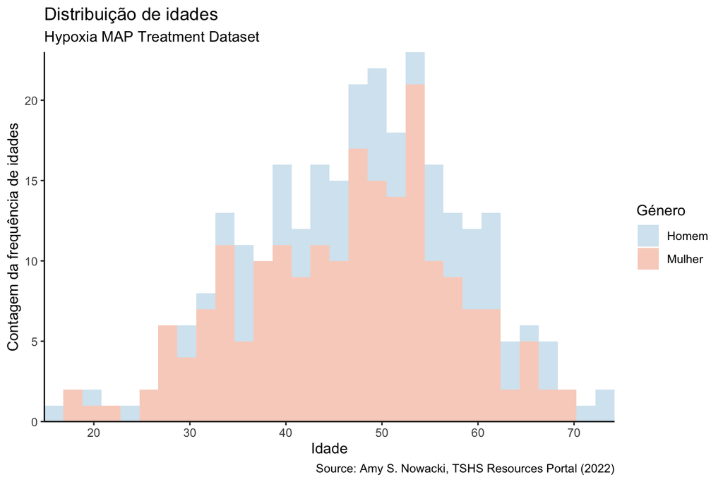

```r
p1<- ggplot(data=hypoxia,
       aes(x=age,
           fill=as.factor(female)
       ) )+
  geom_histogram(alpha=.4) +
    labs(title = "Distribuição de idades",
         subtitle = "Hypoxia MAP Treatment Dataset",
         y = "Contagem da frequência de idades",
         fill= "Género",
         x = "Idade",
         caption = "Source: Amy S. Nowacki, TSHS Resources Portal (2022)") +
  coord_cartesian(expand=FALSE)+
  theme_classic()+
  scale_fill_manual(values=c("#91bfdb","#ef8a62"),
                    labels=c("Homem", "Mulher"))


p2 <- ggplot(data = hypoxia, aes(x = as.factor(female), y = age, fill = as.factor(female))) +
  geom_boxplot(alpha = .4) +
  labs(x = "Género", y = "Idade", fill= "Género") +
  theme_classic() +
  scale_fill_manual(values = c("#91bfdb", "#ef8a62"),
                    labels = c("Homem", "Mulher"))

p1
```

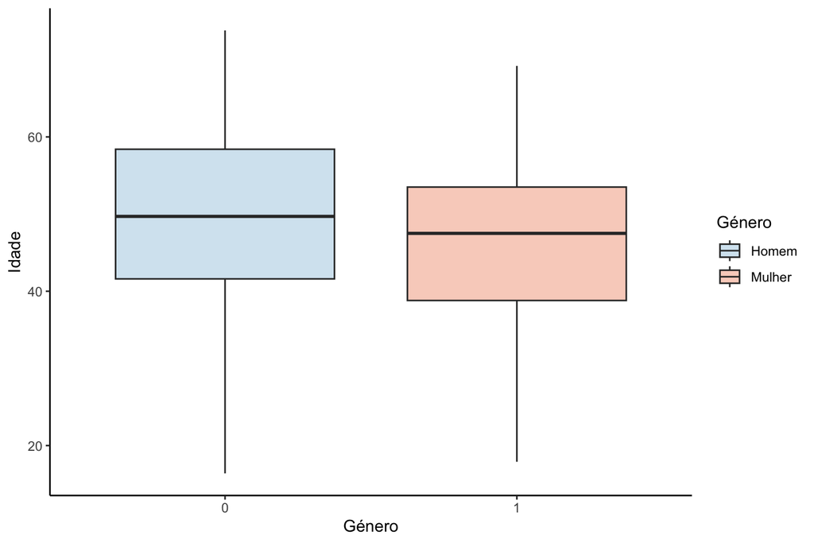

```r
p2
```

## 1.2 Exercicio M4.2 Relação entre variáveis

Explora a relaçao entre MinSao2 e o BMI. O gráfico deve ter um título, caption, legenda. Usa o theme minimal e adiciona uma linha tendência linear para explorar a relação.

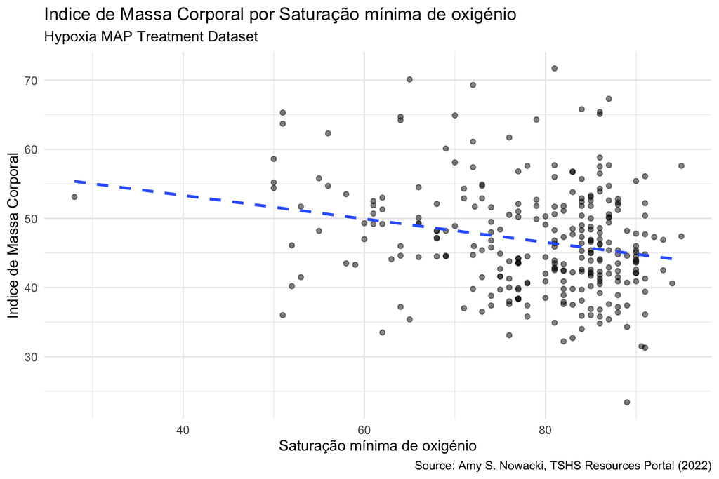

```r
p2<- ggplot(data=hypoxia,
       aes(x=min_sao2,
           y=bmi
       ) )+
  geom_point(alpha=0.5) +
  geom_smooth(method=lm,
              se=FALSE,
              linetype="dashed") +
    labs(title = "Indice de Massa Corporal por Saturação mínima de oxigénio",
         subtitle = "Hypoxia MAP Treatment Dataset",
         y = "Indice de Massa Corporal",
         x = "Saturação mínima de oxigénio",
         caption = "Source: Amy S. Nowacki, TSHS Resources Portal (2022)") +
  theme_minimal()


p2
```

## 1.3 Exercicio M4.3 Mapa

Cria um mapa usado o shapefile comm_pt, e as caracteristicas da base de dados “mortalidade_coracao_2021.csv” na pasta datasets.O mapa deve conter a mortalidade por doenças cardiovasculares com uma escala de 5 cores. O gráfico deve ter um título, caption, legenda.

```r
library(readr)
library(readr)
library(dplyr)
library(janitor)
library(sf)
comm_pt <- st_read(
  "datasets/map_json_portugal/concelhos_portugal_light.json") |>
  clean_names()
mortalidade_coracao_2021 <- read_delim("datasets/mortalidade_coracao_2021.csv",
    delim = ",",
    escape_double = FALSE,
    trim_ws = TRUE)|>
  clean_names() |>
  mutate(
    quintil_mortalidade= as.factor(ntile(valor, n=5))
  )

mortalidade_coracao_2021_mapeado <- left_join(
  comm_pt,
  mortalidade_coracao_2021,
  by= join_by(name_2==geodsg)
)
```

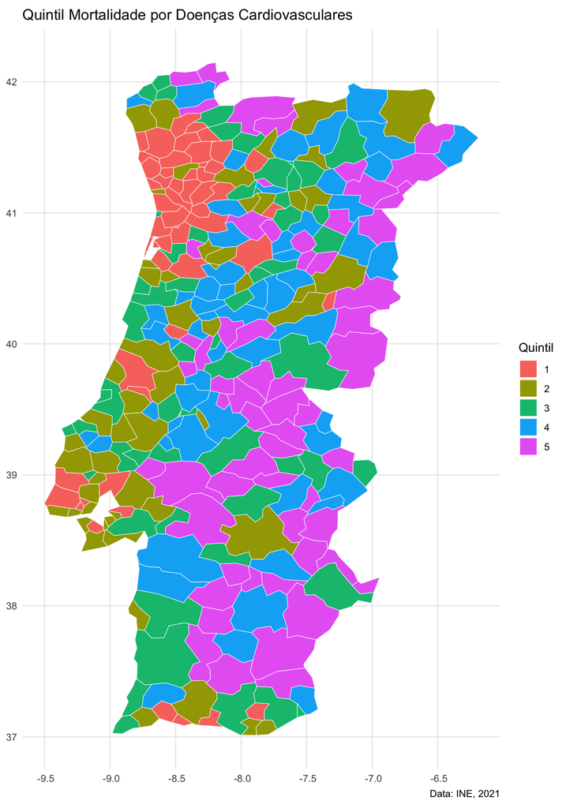

```r
p3 <- ggplot() +
    geom_sf(data = mortalidade_coracao_2021_mapeado,
          aes(fill = quintil_mortalidade),
              size = 0.1,
              color = "white"
          ) +
   theme_minimal() +
    labs(x = NULL,
         y = NULL,
         title = "Quintil Mortalidade por Doenças Cardiovasculares",
         fill= "Quintil",
         caption = "Data: INE, 2021")
p3
```

# 2 FIM

## Notas de rodapé

[^1]: *The Hypoxia MAP dataset was contributed by Dr. Amy Nowacki, Associate Professor, Cleveland Clinic. Please refer to this resource as: Amy S. Nowacki, “Hypoxia MAP Treatment Dataset”, TSHS Resources Portal (2022). Available at https://www.causeweb.org/tshs/hypoxia/.*